# LSTM-PREPROCESSING

```python
#Import Required Libraries

import pandas as pd
import numpy as np

import matplotlib.pyplot as plt
import seaborn as sns

from sklearn.preprocessing import MinMaxScaler

import warnings
warnings.filterwarnings("ignore")
```

```python
# Load dataset

df = pd.read_csv("E:\Project-Report\Crime-Report-UTF.csv")
```

```python
print(df.head())
```

```
            STATE/UT CRIME HEAD  2001  2002  2003  2004  2005  2006  2007  \
0     Andhra Pradesh       RAPE   871  1002   946  1016   935  1049  1070
1  Arunachal Pradesh       RAPE    33    38    31    42    35    37    48
2              Assam       RAPE   817   970  1095  1171  1238  1244  1437
3              Bihar       RAPE   888  1040   985  1390  1147  1232  1555
4       Chhattisgarh       RAPE   959   992   898   969   990   995   982

   2008  2009  2010  2011  2012
0  1257  1188  1362  1442  1341
1    42    59    47    42    46
2  1438  1631  1721  1700  1716
3  1302   929   795   934   927
4   978   976  1012  1053  1034
```

```python
# Display Dataset Information
print(df.info())
```

```
<class 'pandas.core.frame.DataFrame'>
RangeIndex: 324 entries, 0 to 323
Data columns (total 14 columns):
 #   Column      Non-Null Count  Dtype
---  ------      --------------  -----
 0   STATE/UT    324 non-null    object
 1   CRIME HEAD  324 non-null    object
 2   2001        324 non-null    int64
 3   2002        324 non-null    int64
 4   2003        324 non-null    int64
 5   2004        324 non-null    int64
 6   2005        324 non-null    int64
 7   2006        324 non-null    int64
 8   2007        324 non-null    int64
 9   2008        324 non-null    int64
 10  2009        324 non-null    int64
 11  2010        324 non-null    int64
 12  2011        324 non-null    int64
 13  2012        324 non-null    int64
dtypes: int64(12), object(2)
memory usage: 35.6+ KB
None
```

```python
# Dataset Shape
print(df.shape)
```

```
(324, 14)
```

```python
# Column Names
print(df.columns)
```

```
Index(['STATE/UT', 'CRIME HEAD', '2001', '2002', '2003', '2004', '2005',
       '2006', '2007', '2008', '2009', '2010', '2011', '2012'],
      dtype='object')
```

```python
# Statistical Summary
df.describe()
```

|  | 2001 | 2002 | 2003 | 2004 | 2005 | 2006 | 2007 | 2008 | 2009 | 2010 | 2011 | 2012 |
| --- | --- | --- | --- | --- | --- | --- | --- | --- | --- | --- | --- | --- |
| count | 324.000000 | 324.00000 | 324.000000 | 324.000000 | 324.000000 | 324.000000 | 324.000000 | 324.000000 | 324.000000 | 324.000000 | 324.000000 | 324.000000 |
| mean | 1754.654321 | 1748.00000 | 1718.962963 | 1882.623457 | 1899.703704 | 2005.919753 | 2252.716049 | 2383.277778 | 2480.925926 | 2604.641975 | 2781.487654 | 2959.524691 |
| std | 8959.988710 | 8901.83426 | 8777.118834 | 9655.389778 | 9721.530392 | 10324.087197 | 11696.767729 | 12392.687525 | 12981.511763 | 13619.993058 | 14574.198387 | 15555.176191 |
| min | 0.000000 | 0.00000 | 0.000000 | 0.000000 | 0.000000 | 0.000000 | 0.000000 | 0.000000 | 0.000000 | 0.000000 | 0.000000 | 0.000000 |
| 25% | 3.000000 | 3.00000 | 2.000000 | 4.000000 | 4.000000 | 5.000000 | 5.000000 | 4.000000 | 4.000000 | 4.000000 | 3.000000 | 5.000000 |
| 50% | 64.000000 | 72.00000 | 81.500000 | 82.000000 | 92.000000 | 102.000000 | 90.000000 | 91.000000 | 106.000000 | 91.500000 | 94.500000 | 96.000000 |
| 75% | 771.250000 | 799.50000 | 815.500000 | 881.500000 | 842.750000 | 948.750000 | 983.000000 | 998.250000 | 958.500000 | 1025.750000 | 1057.500000 | 1130.250000 |
| max | 143795.000000 | 143034.00000 | 140601.000000 | 154333.000000 | 155553.000000 | 164765.000000 | 185312.000000 | 195857.000000 | 203804.000000 | 213585.000000 | 228650.000000 | 244270.000000 |

Interpretation

Provides

Average crime counts Dispersion Maximum reported crimes Minimum crime counts

```python
# Check Missing Values
df.isnull().sum()
```

```
STATE/UT      0
CRIME HEAD    0
2001          0
2002          0
2003          0
2004          0
2005          0
2006          0
2007          0
2008          0
2009          0
2010          0
2011          0
2012          0
dtype: int64
```

```python
# Check Duplicate Records
df.duplicated().sum()
```

```
np.int64(0)
```

```python
# Check Unique States
print(df["STATE/UT"].unique())
```

```
['Andhra Pradesh' 'Arunachal Pradesh' 'Assam' 'Bihar' 'Chhattisgarh' 'Goa'
 'Gujarat' 'Haryana' 'Himachal Pradesh' 'Jammu & Kashmir' 'Jharkhand'
 'Karnataka' 'Kerala' 'Madhya Pradesh' 'Maharashtra' 'Manipur' 'Meghalaya'
 'Mizoram' 'Nagaland' 'Odisha' 'Punjab' 'Rajasthan' 'Sikkim' 'Tamil Nadu'
 'Tripura' 'Uttar Pradesh' 'Uttarakhand' 'West Bengal' 'A&N Islands'
 'Chandigarh' 'D&N Haveli' 'Daman & Diu' 'Delhi UT' 'Lakshadweep'
 'Puducherry' 'All India' 'ALL INDIA K&A' 'ALL INDIA '
 'TOTAL Crime against Women']
```

```python
# Number of States
print(df["STATE/UT"].nunique())
```

```
39
```

```python
#Crime Categories
print(df["CRIME HEAD"].unique())
```

```
['RAPE' 'KIDNAPPING & ABDUCTION' 'DOWRY DEATH'
 'ASSAULT ON WOMEN WITH INTENT TO OUTRAGE HER MODESTY'
 'INSULT TO THE MODESTY OF WOMEN' 'CRUELTY BY HUSBAND OR RELATIVES'
 'IMMORAL TRAFFIC(PREVENTION)ACT'
 'INDECENT REPRESENTATION OF WOMEN(PREVENTION)ACT'
 'TOTAL CRIMES AGAINST WOMEN']
```

```python
# Select Required Crime Categories

crime_list = [

"RAPE",

"DOWRY DEATHS",

"KIDNAPPING",

"SEXUAL HARASSMENT",

"CRUELTY BY HUSBAND OR HIS RELATIVES"

]
```

```python
# Convert Wide Format to Long Format

df_long = pd.melt(

df,

id_vars=["STATE/UT","CRIME HEAD"],

var_name="Year",

value_name="Crime Count"

)

print(df_long.head())
```

```
            STATE/UT CRIME HEAD  Year  Crime Count
0     Andhra Pradesh       RAPE  2001          871
1  Arunachal Pradesh       RAPE  2001           33
2              Assam       RAPE  2001          817
3              Bihar       RAPE  2001          888
4       Chhattisgarh       RAPE  2001          959
```

```python
# Convert Year into Integer
df_long["Year"] = df_long["Year"].astype(int)
```

```python
# Check Data Types

df_long.dtypes
```

```
STATE/UT       object
CRIME HEAD     object
Year            int64
Crime Count     int64
dtype: object
```

```python
# Descriptive Statistics
df_long.describe()
```

|  | Year | Crime Count |
| --- | --- | --- |
| count | 3888.000000 | 3888.000000 |
| mean | 2006.500000 | 2206.036523 |
| std | 3.452497 | 11644.440365 |
| min | 2001.000000 | 0.000000 |
| 25% | 2003.750000 | 4.000000 |
| 50% | 2006.500000 | 87.000000 |
| 75% | 2009.250000 | 922.000000 |
| max | 2012.000000 | 244270.000000 |

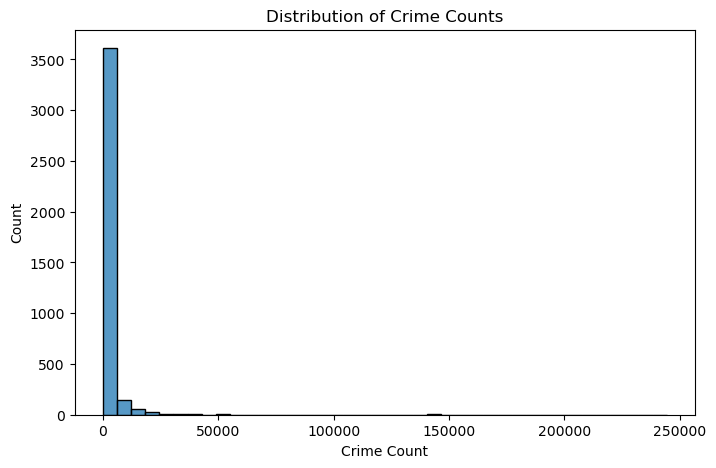

```python
# Distribution of Crime Counts
plt.figure(figsize=(8,5))

sns.histplot(df_long["Crime Count"], bins=40)

plt.title("Distribution of Crime Counts")

plt.show()
```

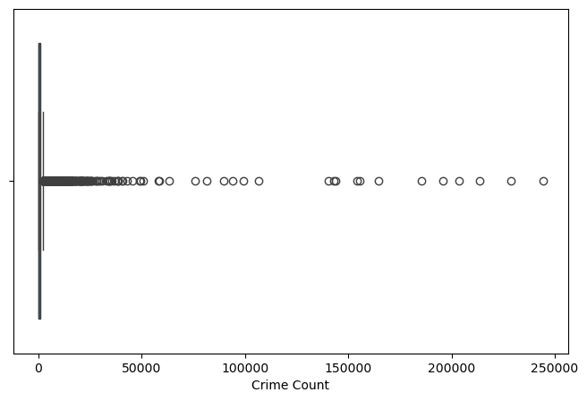

```python
# Box Plot
plt.figure(figsize=(8,5))

sns.boxplot(x=df_long["Crime Count"])

plt.show()
```

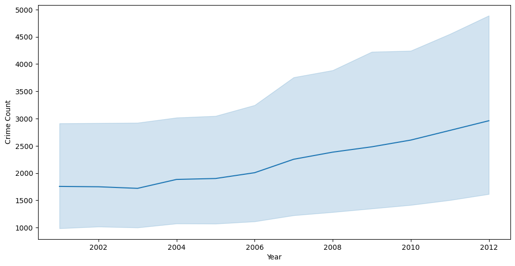

```python
# Year-wise Crime Trend
plt.figure(figsize=(12,6))

sns.lineplot(

data=df_long,

x="Year",

y="Crime Count"

)
```

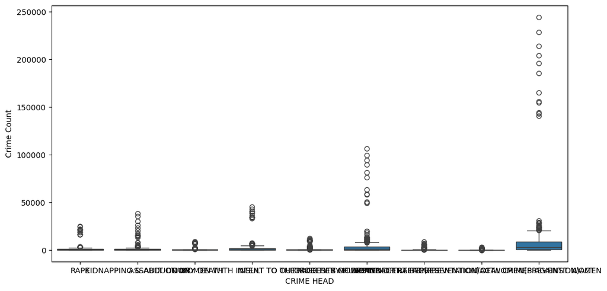

```python
# Crime Category Comparison
plt.figure(figsize=(12,6))

sns.boxplot(

data=df_long,

x="CRIME HEAD",

y="Crime Count"

)
```

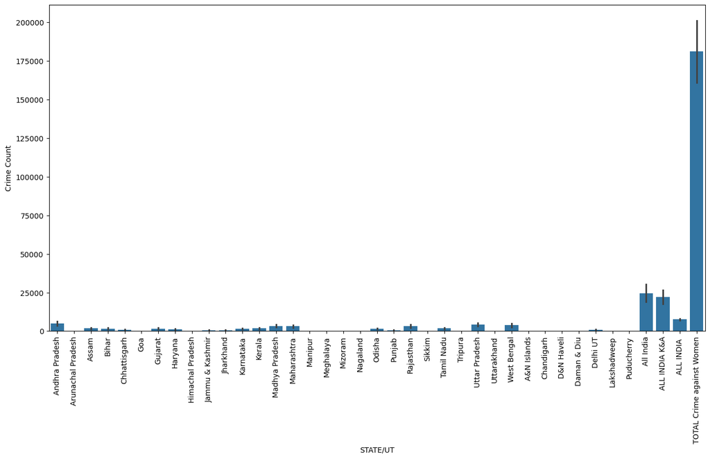

```python
# State-wise Crime Distribution
plt.figure(figsize=(16,8))

sns.barplot(

data=df_long,

x="STATE/UT",

y="Crime Count"

)

plt.xticks(rotation=90)

plt.show()
```

Interpretation

Highlights states with comparatively higher reported crime counts.

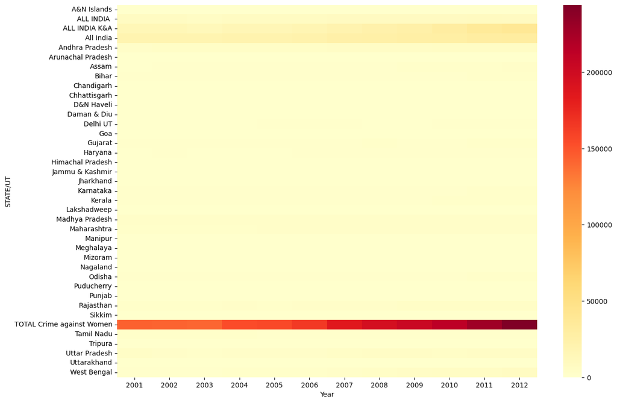

```python
# Heatmap of Crime Counts
pivot = df_long.pivot_table(

values="Crime Count",

index="STATE/UT",

columns="Year"

)

plt.figure(figsize=(14,10))

sns.heatmap(

pivot,

cmap="YlOrRd"

)

plt.show()
```

Interpretation

Darker colors indicate higher crime counts. Enables visual comparison across states and years.

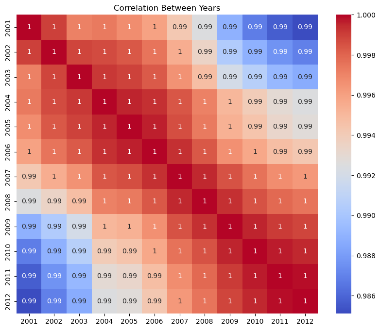

```python
# Correlation Matrix
numeric_df = df.drop(columns=["STATE/UT", "CRIME HEAD"])

corr = numeric_df.corr()

plt.figure(figsize=(10,8))

sns.heatmap(corr, annot=True, cmap="coolwarm")

plt.title("Correlation Between Years")

plt.show()
```

Interpretation

Strong positive correlations between adjacent years suggest temporal continuity. Supports the use of sequence-based models like LSTM and GRU.

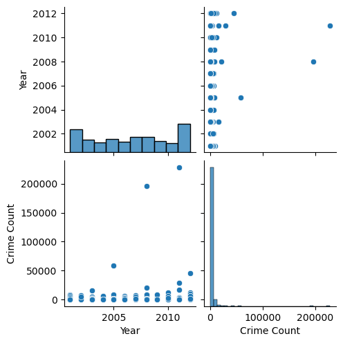

```python
# Pair Plot
sns.pairplot(df_long.sample(300))
```

Purpose

Explores pairwise relationships between variables.

Observations from EDA

```python
# Sorting Dataset

# Time-series must be chronologically ordered.
df = df_long.sort_values(
    by=["STATE/UT","CRIME HEAD","Year"]
)
```

```python
df["Lag1"] = (
     df_long.groupby(["STATE/UT","CRIME HEAD"])
      ["Crime Count"]
      .shift(1)
)
```

```python
df["Lag2"] = (
    df_long.groupby(["STATE/UT","CRIME HEAD"])
      ["Crime Count"]
      .shift(2)
)
```

```python
# Rolling Mean
df["RollingMean"] = (
    df_long.groupby(["STATE/UT","CRIME HEAD"])
      ["Crime Count"]
      .rolling(3)
      .mean()
      .reset_index(level=[0,1],drop=True)
)
```

```python
# Rolling Standard Deviation
df["RollingStd"] = (
    df_long.groupby(["STATE/UT","CRIME HEAD"])
      ["Crime Count"]
      .rolling(3)
      .std()
      .reset_index(level=[0,1],drop=True)
)
```

```python
# Growth Rate
df["GrowthRate"] = (
    df_long.groupby(["STATE/UT","CRIME HEAD"])
      ["Crime Count"]
      .pct_change()
)
```

```python
# Remove NaN Values
df = df.dropna()
```

```python
# Apply Min-Max Scaling
from sklearn.preprocessing import MinMaxScaler

scaler = MinMaxScaler()

df["Crime Count"] = scaler.fit_transform(
    df[["Crime Count"]]
)
```

```python
# Verify Scaling
print(df["Crime Count"].min())
print(df["Crime Count"].max())
```

```
0.0
0.9999999999999999
```

```python
# Create Sequence Function
import numpy as np

def create_sequences(data, sequence_length):

    X = []
    y = []

    for i in range(len(data)-sequence_length):

        X.append(data[i:i+sequence_length])

        y.append(data[i+sequence_length])

    return np.array(X), np.array(y)
```

```python
# Generate Sequences
sequence_length = 3

X, y = create_sequences(
    df["Crime Count"].values,
    sequence_length
)
```

```python
# Check Shapes
print(X.shape)
print(y.shape)
```

```
(2817, 3)
(2817,)
```

```python
# Reshape Dataset
X = X.reshape(
    X.shape[0],
    X.shape[1],
    1
)
```

```python
# Verify Shape
print(X.shape)
```

```
(2817, 3, 1)
```

Interpretation

2817 samples 3 time steps 1 feature

```python
# Train-Test Split
from sklearn.model_selection import train_test_split

X_train, X_test, y_train, y_test = train_test_split(

    X,

    y,

    test_size=0.20,

    shuffle=False
)
```

```python
# Final Dataset Shapes
print("Training :", X_train.shape)

print("Testing :", X_test.shape)
```

```
Training : (2253, 3, 1)
Testing : (564, 3, 1)
```

```python
# Complete Preprocessing Pipeline
from sklearn.preprocessing import MinMaxScaler
import numpy as np

# Normalize
scaler = MinMaxScaler()

scaled = scaler.fit_transform(
    df[["Crime Count"]]
)

# Sequence generation
sequence_length = 3

X, y = create_sequences(
    scaled,
    sequence_length
)

# Reshape
X = X.reshape(
    X.shape[0],
    sequence_length,
    1
)
```

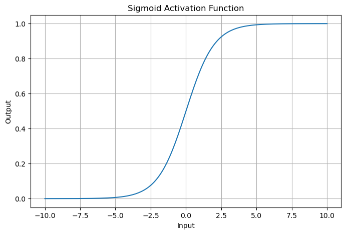

```python
import numpy as np
import matplotlib.pyplot as plt

x = np.linspace(-10, 10, 200)

sigmoid = 1 / (1 + np.exp(-x))

plt.figure(figsize=(8,5))
plt.plot(x, sigmoid)
plt.title("Sigmoid Activation Function")
plt.xlabel("Input")
plt.ylabel("Output")
plt.grid(True)
plt.show()
```

Expected Output

An S-shaped curve with values ranging from 0 to 1.

Interpretation Used in LSTM and GRU gates. Produces probabilities. Controls information flow.

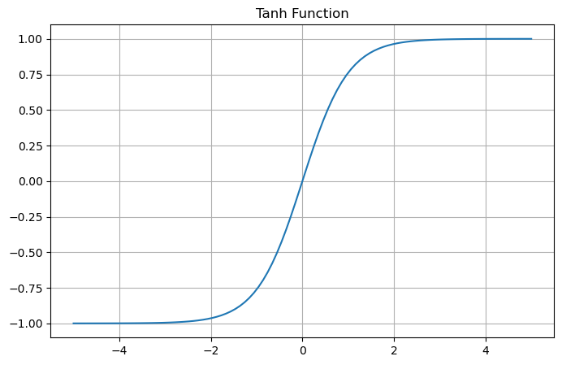

```python
import numpy as np
import matplotlib.pyplot as plt

x = np.linspace(-5,5,100)

y = np.tanh(x)

plt.figure(figsize=(8,5))
plt.plot(x,y)
plt.title("Tanh Function")
plt.grid(True)
plt.show()
```

Interpretation

Produces zero-centered outputs and is commonly used to create candidate memory states in LSTM and GRU.

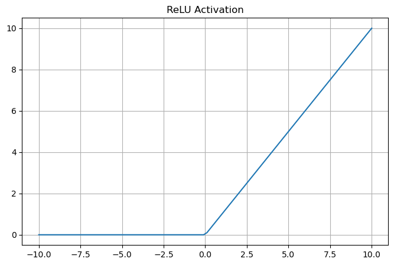

```python
# ractical 3 — ReLU
import numpy as np
import matplotlib.pyplot as plt

x = np.linspace(-10,10,100)

relu = np.maximum(0,x)

plt.figure(figsize=(8,5))
plt.plot(x,relu)
plt.title("ReLU Activation")
plt.grid(True)
plt.show()
```

```python
# Practical 4 — Single Artificial Neuron
import numpy as np

x = np.array([2,4])

w = np.array([0.5,0.3])

b = 0.2

z = np.dot(x,w)+b

print(z)
```

```
2.4000000000000004
```

```python
# Apply sigmoid
y = 1/(1+np.exp(-z))

print(y)
```

```
0.9168273035060777
```

```python
# Feed Forward Neural Network
import os
import joblib
import warnings
warnings.filterwarnings("ignore")

import numpy as np
import pandas as pd

import matplotlib.pyplot as plt

from sklearn.metrics import (
    mean_squared_error,
    mean_absolute_error,
    r2_score
)

from tensorflow.keras.models import Sequential
from tensorflow.keras.layers import (
    LSTM,
    Dense,
    Dropout
)

from tensorflow.keras.callbacks import (
    EarlyStopping,
    ModelCheckpoint,
    ReduceLROnPlateau
)

from tensorflow.keras.optimizers import Adam
```

```python
model = Sequential()

model.add(
    LSTM(
        units=64,
        return_sequences=True,
        input_shape=(X_train.shape[1],1)
    )
)

model.add(Dropout(0.20))

model.add(
    LSTM(
        units=32
    )
)

model.add(Dropout(0.20))

model.add(Dense(16,activation="relu"))

model.add(Dense(1))
```

```python
# Display Model Summary
model.summary()
```

```
Model: "sequential"
```

```
┏━━━━━━━━━━━━━━━━━━━━━━━━━━━━━━━━━━━━━━┳━━━━━━━━━━━━━━━━━━━━━━━━━━━━━┳━━━━━━━━━━━━━━━━━┓
┃ Layer (type)                         ┃ Output Shape                ┃         Param # ┃
┡━━━━━━━━━━━━━━━━━━━━━━━━━━━━━━━━━━━━━━╇━━━━━━━━━━━━━━━━━━━━━━━━━━━━━╇━━━━━━━━━━━━━━━━━┩
│ lstm (LSTM)                          │ (None, 3, 64)               │          16,896 │
├──────────────────────────────────────┼─────────────────────────────┼─────────────────┤
│ dropout (Dropout)                    │ (None, 3, 64)               │               0 │
├──────────────────────────────────────┼─────────────────────────────┼─────────────────┤
│ lstm_1 (LSTM)                        │ (None, 32)                  │          12,416 │
├──────────────────────────────────────┼─────────────────────────────┼─────────────────┤
│ dropout_1 (Dropout)                  │ (None, 32)                  │               0 │
├──────────────────────────────────────┼─────────────────────────────┼─────────────────┤
│ dense (Dense)                        │ (None, 16)                  │             528 │
├──────────────────────────────────────┼─────────────────────────────┼─────────────────┤
│ dense_1 (Dense)                      │ (None, 1)                   │              17 │
└──────────────────────────────────────┴─────────────────────────────┴─────────────────┘
```

```
 Total params: 29,857 (116.63 KB)
```

```
 Trainable params: 29,857 (116.63 KB)
```

```
 Non-trainable params: 0 (0.00 B)
```

```python
# Model Compilation
optimizer = Adam(
    learning_rate=0.001
)

model.compile(

    optimizer=optimizer,

    loss="mse",

    metrics=["mae"]

)
```

```
WARNING:tensorflow:TensorFlow GPU support is not available on native Windows for TensorFlow >= 2.11. Even if CUDA/cuDNN are installed, GPU will not be used. Please use WSL2 or the TensorFlow-DirectML plugin.
```

```python
# Callbacks
early_stop = EarlyStopping(

    monitor="val_loss",

    patience=20,

    restore_best_weights=True

)
```

```python
# Model Checkpoint
checkpoint = ModelCheckpoint(

    "models/lstm_model.keras",

    monitor="val_loss",

    save_best_only=True

)
```

```python
# Learning Rate Scheduler
reduce_lr = ReduceLROnPlateau(

    monitor="val_loss",

    factor=0.5,

    patience=10,

    verbose=1

)
```

```python
# Train the LSTM Model
history = model.fit(

    X_train,

    y_train,

    epochs=10,

    batch_size=8,

    callbacks=[

        early_stop,

        checkpoint,

        reduce_lr

    ],

    verbose=1

)
```

```
282/282 ━━━━━━━━━━━━━━━━━━━━ 1s 4ms/step - loss: 1.3085e-04 - mae: 0.0045 - learning_rate: 0.0010
282/282 ━━━━━━━━━━━━━━━━━━━━ 1s 4ms/step - loss: 1.3051e-04 - mae: 0.0041 - learning_rate: 0.0010
282/282 ━━━━━━━━━━━━━━━━━━━━ 1s 4ms/step - loss: 1.2037e-04 - mae: 0.0037 - learning_rate: 0.0010
282/282 ━━━━━━━━━━━━━━━━━━━━ 1s 4ms/step - loss: 1.3349e-04 - mae: 0.0038 - learning_rate: 0.0010
282/282 ━━━━━━━━━━━━━━━━━━━━ 1s 4ms/step - loss: 1.2849e-04 - mae: 0.0039 - learning_rate: 0.0010
282/282 ━━━━━━━━━━━━━━━━━━━━ 1s 4ms/step - loss: 1.1303e-04 - mae: 0.0039 - learning_rate: 0.0010
282/282 ━━━━━━━━━━━━━━━━━━━━ 1s 4ms/step - loss: 1.1954e-04 - mae: 0.0038 - learning_rate: 0.0010
282/282 ━━━━━━━━━━━━━━━━━━━━ 1s 4ms/step - loss: 1.2333e-04 - mae: 0.0039 - learning_rate: 0.0010
282/282 ━━━━━━━━━━━━━━━━━━━━ 1s 4ms/step - loss: 1.0989e-04 - mae: 0.0038 - learning_rate: 0.0010
282/282 ━━━━━━━━━━━━━━━━━━━━ 1s 4ms/step - loss: 1.1365e-04 - mae: 0.0039 - learning_rate: 0.0010
```

```python
# Save Final Model
model.save(
    "models/final_lstm.keras"
)
```

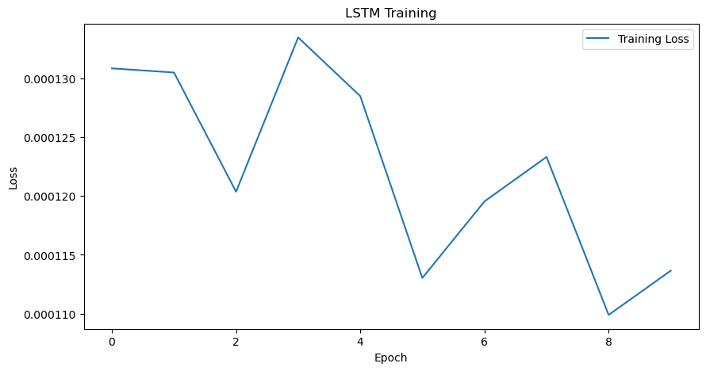

```python
# Plot Training Loss

plt.figure(figsize=(10,5))

plt.plot(

    history.history["loss"],

    label="Training Loss"

)

plt.plot(

    label="Validation Loss"

)

plt.xlabel("Epoch")

plt.ylabel("Loss")

plt.title("LSTM Training")

plt.legend()

plt.show()
```

```python
# Prediction
predictions = model.predict(
    X_test
)
```

```
18/18 ━━━━━━━━━━━━━━━━━━━━ 1s 18ms/step
```